# Housing Price Prediction

Ruochen Ma

December 12, 2018

# Introduciton

This project is about predicting the housing price based a large number of predictor. Here I apply a number of machine learning techniques and regression methods such as random forest, boosting, dimension reduction and linear regularization in an attempt to build a model that has the best prediction performance. The data set comes from Kaggle.com which contains around 1500 records of house sale prices in the city of Ames, Iowa. Togehter with the data comes 79 different detailed decriptions about each individual house. These range from the basic information such as number of rooms and total square footage to many other more specific measures that may not come into the mind of a typical house buyer, such as proximity to railroad, furnished area of the basement, etc. Due to the large number of predictors, there is a need to do feature engineering and variable selection before building the model to avoid overfitting. Here I first deal with the the missing data and then performs a number of refinements on the original predictors, which involve recoding some of the factor variables, creating new variables more suitable for model building, and dropping highly correlated extra information.

# Missing data

## Check for missing data

First I check the number of missing values in the data set. The table below gives the variables that have missing data and the proportion of missing values that they have.

```r
setwd("C:/Users/olive/Desktop/Fall 2018/Predictive Analytics/Housing Price project")

housing <- read.csv("train.csv", header = T)

library(dplyr)


# Check for missing data

missing <- sapply(housing, function(x) sum(is.na(x))/nrow(housing))
cbind(missing[missing > 0])
```

```
##                      [,1]
## LotFrontage  0.1773972603
## Alley        0.9376712329
## MasVnrType   0.0054794521
## MasVnrArea   0.0054794521
## BsmtQual     0.0253424658
## BsmtCond     0.0253424658
## BsmtExposure 0.0260273973
## BsmtFinType1 0.0253424658
## BsmtFinType2 0.0260273973
## Electrical   0.0006849315
## FireplaceQu  0.4726027397
## GarageType   0.0554794521
## GarageYrBlt  0.0554794521
## GarageFinish 0.0554794521
## GarageQual   0.0554794521
## GarageCond   0.0554794521
## PoolQC       0.9952054795
## Fence        0.8075342466
## MiscFeature  0.9630136986
```

As you can see, there are a total of 19 variables with NA’s in them, some of which have more than 90% of these. However, due to the nature of this data set, the majority of the NA values here are not really missing data but rather represent a categorical level that is not availble for a particular house. For example, the PoolQC has about 99% of its values being NA, this is simply because these houses do not have a pool. Therefore we can easilty change these into a new factor level.

## Imputing missing data

Here I deal with the NA values in each of these variables according to their cause of occurence.

You can click on the tabs to see what I did for each of the variables.

### Alley

This variable describes the types of the alley acess, where NA means no alley access. Therefore we can simply replace NA with a new factor level “No alley”.

```r
###
str(housing$Alley) # type of alley, NA means no alley
```

```
##  Factor w/ 2 levels "Grvl","Pave": NA NA NA NA NA NA NA NA NA NA ...
```

```r
# NA means no alley, we can treat this as another factor level
housing$Alley <- as.character(housing$Alley)
housing$Alley[is.na(housing$Alley)] <- "No alley"
housing$Alley <- factor(housing$Alley)
###
```

### MasVnrType & MasVnrArea

These are the Masonry veneer type and Masonry veneer area. Assuming that NA means no Masonry veneer wall for the house, I recoded them accordingly and set the Masonry area to 0 for these houses.

```r
###
levels(housing$MasVnrType) # Masonry veneer type
```

```
## [1] "BrkCmn"  "BrkFace" "None"    "Stone"
```

```r
str(housing$MasVnrArea) # Masonry veneer area
```

```
##  int [1:1460] 196 0 162 0 350 0 186 240 0 0 ...
```

```r
which(is.na(housing$MasVnrType))
```

```
## [1]  235  530  651  937  974  978 1244 1279
```

```r
which(is.na(housing$MasVnrArea))
```

```
## [1]  235  530  651  937  974  978 1244 1279
```

```r
# The houses with missing masorny area is also missing masonry type
# Assuming these are houses that do not have a masonry veneer
# Replace NA with "None"

housing$MasVnrType <- as.character(housing$MasVnrType)
housing$MasVnrType[is.na(housing$MasVnrType)] <- "None"
housing$MasVnrType <- factor(housing$MasVnrType)

# No masonry wall means there is no area measurements. We can set these to 0 instead of NA
housing$MasVnrArea[is.na(housing$MasVnrArea)] <- 0
```

### Basement measures

There are a variety of measures about basement in this data set. Again the NA’s here mean that the house does not have a particular feature for the basement or simply no basement.

```r
levels(housing$BsmtQual) # Evaluates the height of the basement, NA no basement
```

```
## [1] "Ex" "Fa" "Gd" "TA"
```

```r
levels(housing$BsmtCond) # general condition of the basement, NA no basement
```

```
## [1] "Fa" "Gd" "Po" "TA"
```

```r
levels(housing$BsmtExposure) # Basement exposure, NA no basement
```

```
## [1] "Av" "Gd" "Mn" "No"
```

```r
levels(housing$BsmtFinType1) # Rating of basement finished area, NA no basement
```

```
## [1] "ALQ" "BLQ" "GLQ" "LwQ" "Rec" "Unf"
```

```r
levels(housing$BsmtFinType2) #Rating of basement finished area (if multiple types)
```

```
## [1] "ALQ" "BLQ" "GLQ" "LwQ" "Rec" "Unf"
```

```r
# In all these cases regarding basement, NA means no basement, treat NA as another factor level

# a function that substitute NA with a new factor level
nasubfactor <- function(v, repl){
  housing[[v]] <<- as.character(housing[[v]])
  housing[[v]][is.na(housing[[v]])] <<- repl
}

v <- c("BsmtQual", "BsmtCond", "BsmtExposure", "BsmtFinType1", "BsmtFinType2")
invisible(sapply(v, nasubfactor, repl = "No Basement"))
```

Since several of these variables are ratings that has a natural ordering, we can label them with integers to reflect the ordinal structure. Here I give a score the house, where 0 means no basement and higher score means better conditions or qualities measured for that basement.

```r
housing$BsmtQual <- as.integer(recode(housing$BsmtQual, "No Basement" = 0,
                           "Po" = 1, "Fa" = 2, "TA" = 3, "Gd" = 4,
                           "Ex" = 5))
housing$BsmtCond <- as.integer(recode(housing$BsmtCond, "No Basement" = 0,
                           "Po" = 1, "Fa" = 2, "TA" = 3, "Gd" = 4,
                           "Ex" = 5))
housing$BsmtExposure <- as.integer(recode(housing$BsmtExposure,
                                          "No Basement" = 0, "No" = 1,
                                          "Mn" = 2, "Av" = 3, "Gd" = 4))
housing$BsmtFinType1 <- as.integer(recode(housing$BsmtFinType1,
                                          "No Basement" = 0, "Unf" = 1,
                                          "LwQ" = 2, "Rec" = 3,
                                          "BLQ" = 4, "ALQ" = 5, "GLQ" = 6))

housing$BsmtFinType2 <- as.integer(recode(housing$BsmtFinType2,
                                          "No Basement" = 0, "Unf" = 1,
                                          "LwQ" = 2, "Rec" = 3,
                                          "BLQ" = 4, "ALQ" = 5, "GLQ" = 6))
```

### Fireplace Quality

Again, this is a rating system, NA means no fireplace. Label the ratings with integers.

```r
levels(housing$FireplaceQu) # Fireplace quality, NA means no fireplace
```

```
## [1] "Ex" "Fa" "Gd" "Po" "TA"
```

```r
nasubfactor(v = "FireplaceQu", repl = "No Fireplace")

housing$FireplaceQu <- as.integer(recode(housing$FireplaceQu,
                                         "No Fireplace" = 0, "Po" = 1,"Fa" = 2, "TA" = 3, "Gd" = 4, "Ex" = 5))
```

### Garage

For these measures about garage, NA means there is no garage. Again, for these ranks and ratings, I created a score for each level of the rating. In addition, for the variable year when garage is built, I separated the years into a factor with 5 levels with NA being one level and the others based on the quantiles of all the years.

```r
levels(housing$GarageType) # Garage location, NA no garage
```

```
## [1] "2Types"  "Attchd"  "Basment" "BuiltIn" "CarPort" "Detchd"
```

```r
levels(housing$GarageFinish) # Garage finish, NA no garage
```

```
## [1] "Fin" "RFn" "Unf"
```

```r
levels(housing$GarageQual) # Garage quality, NA no garage
```

```
## [1] "Ex" "Fa" "Gd" "Po" "TA"
```

```r
levels(housing$GarageCond) # Garage condition, NA no garage
```

```
## [1] "Ex" "Fa" "Gd" "Po" "TA"
```

```r
str(housing$GarageYrBlt) # Garage year built
```

```
##  int [1:1460] 2003 1976 2001 1998 2000 1993 2004 1973 1931 1939 ...
```

```r
v <- c("GarageType","GarageFinish", "GarageQual", "GarageCond")
invisible(sapply(v, nasubfactor, repl = "No Garage"))

housing$GarageQual <- as.integer(recode(housing$GarageQual,
                                        "No Garage" = 0, "Po" = 1,"Fa" = 2, "TA" = 3, "Gd" = 4, "Ex" = 5))
housing$GarageCond <- as.integer(recode(housing$GarageCond,
                                        "No Garage" = 0, "Po" = 1,"Fa" = 2, "TA" = 3, "Gd" = 4, "Ex" = 5))

housing$GarageType <- factor(housing$GarageType)
housing$GarageFinish <- factor(housing$GarageFinish)

summary(housing$GarageYrBlt)
```

```
##    Min. 1st Qu.  Median    Mean 3rd Qu.    Max.    NA's
##    1900    1961    1980    1979    2002    2010      81
```

```r
# treat this as a categorical variable

a <- c()
a[which(housing$GarageYrBlt >= 2002)] <- "2002 and newer"
a[which(housing$GarageYrBlt < 2002 & housing$GarageYrBlt >=1980)] <- "1980 ~ 2002"
a[which(housing$GarageYrBlt < 1980 & housing$GarageYrBlt >= 1961)] <- "1961 ~ 1980"
a[which(housing$GarageYrBlt < 1961)] <- "1961 and older"
a[which(is.na(housing$GarageYrBlt))] <- "No Garage"

housing$GarageYrBlt <- factor(a)
```

### Pool and Fence Quality

These are quality ratings for pools and fence. NA means no pool or fence.

```r
levels(housing$PoolQC) # pool quality, NA no pool
```

```
## [1] "Ex" "Fa" "Gd"
```

```r
nasubfactor("PoolQC", "No Pool")

housing$PoolQC <- as.integer(recode(housing$PoolQC, "No Pool" = 0,
                                    "Po" = 1,"Fa" = 2, "TA" = 3, "Gd" = 4, "Ex" = 5))

levels(housing$Fence) # Fence quality, NA no fence
```

```
## [1] "GdPrv" "GdWo"  "MnPrv" "MnWw"
```

```r
nasubfactor("Fence", "No Fence")
housing$Fence <- as.integer(recode(housing$Fence, "No Fence" = 0,
                                    "MnWw" = 1,"GdWo" = 2, "MnPrv" = 3, "GdPrv" = 4))
```

### MiscFeature

There are other factors not covered in the other categories, where NA means no such factors for that house. Since it does not have a ordinal structure, I keep it as a factor.

```r
levels(housing$MiscFeature) # Miscellaneous feature not covered in other categories, NA means none
```

```
## [1] "Gar2" "Othr" "Shed" "TenC"
```

```r
nasubfactor("MiscFeature", "None of these")
housing$MiscFeature <- factor(housing$MiscFeature)
```

### Lot Frontage and Electrical system

Two remaing variables are still with missing values. Unlike the other varibles where NA is a categorical level, here they really have missing values that are missing at random. Fortunately the proportion of values missing is relatively small. Here I use a K nearest neighbor imputation to impute them.

```r
str(housing$LotFrontage) # int
```

```
##  int [1:1460] 65 80 68 60 84 85 75 NA 51 50 ...
```

```r
sum(is.na(housing$LotFrontage))
```

```
## [1] 259
```

```r
str(housing$Electrical) # Electrical system
```

```
##  Factor w/ 5 levels "FuseA","FuseF",..: 5 5 5 5 5 5 5 5 2 5 ...
```

```r
levels(housing$Electrical)
```

```
## [1] "FuseA" "FuseF" "FuseP" "Mix"   "SBrkr"
```

```r
sum(is.na(housing$Electrical))
```

```
## [1] 1
```

```r
# so there is only one observation with missing electrical system
# Impute them with KNN

library(DMwR)

housing1 <- knnImputation(data = housing)

sum(is.na(housing1))
```

```
## [1] 0
```

# Feature Engineering

After dealing with all the missing values in the data, now I take a further look at the variables and ajust them in a number of ways that can help the model building process.

You can click on the tabs to see what I did for each of the variables that I worked on.

## MSSubClass

Although this is recorded as an integer, this is actually a norminal categorical variable so the values of the numbers do not really have any meanings. Therefore I recode it as a factor.

```r
housing1 <- housing1[,-1]

# MSSubClass is a categorical variable instead of numeric

housing1$MSSubClass <- factor(housing1$MSSubClass)
```

## Year house built and remodeled

Since the year house built and year house remodeled are highly correlated, and the majority of the house did not have any remodeling so the two years are the same, here I drop the Year remodeled variable. However, instead I created an indicator variable suggesting whether or not the house has been remodeled.

In addition, I created a variable of the house age when sold which is equal to year house sold - year house built and drop the orignal variables. This can be more important to the prediction.

```r
# Here I create a variable indicating whether the house has been remodeled

housing1$remodel <- ifelse(housing1$YearBuilt == housing1$YearRemodAdd, "No", "Yes")
housing1$remodel <- factor(housing1$remodel)

# In addition, I create a variable house age = year house sold -  year built

housing1$houseage <- housing1$YrSold - housing1$YearBuilt


# Drop the unused year variables

housing1 <- select(housing1, -YearBuilt, - YearRemodAdd, -YrSold)
```

## Basement ratings

There are two different ratings for different types of basement finish type, each also comes with a total square footage measured for that finish type. This is rather redundant so here I create an overall weighted average score for the finish rating, using areas for each type as weight, which is calculated as below:
$$BsmtFinRating=\frac{type_1(rating)*type_1(area)+type_2(rating)*type_2(area)}{type_1(area)+type_2(area)}$$

```r
# Basement, weighted overall finish rating
summary(housing1$BsmtFinType1)
```

```
##    Min. 1st Qu.  Median    Mean 3rd Qu.    Max.
##   0.000   1.000   4.000   3.546   6.000   6.000
```

```r
summary(housing1$BsmtFinType2)
```

```
##    Min. 1st Qu.  Median    Mean 3rd Qu.    Max.
##   0.000   1.000   1.000   1.247   1.000   6.000
```

```r
summary(housing1$BsmtFinSF1)
```

```
##    Min. 1st Qu.  Median    Mean 3rd Qu.    Max.
##     0.0     0.0   383.5   443.6   712.2  5644.0
```

```r
summary(housing1$BsmtFinSF1)
```

```
##    Min. 1st Qu.  Median    Mean 3rd Qu.    Max.
##     0.0     0.0   383.5   443.6   712.2  5644.0
```

```r
housing1$BsmtFinrating <- ifelse(housing1$BsmtFinSF1 == 0 & housing1$BsmtFinSF2 == 0, 0,
                                 housing1$BsmtFinSF1*housing1$BsmtFinType1 + housing1$BsmtFinSF2*
                                   housing1$BsmtFinType2/(housing1$BsmtFinSF1 +
                                                             housing1$BsmtFinSF2))
```

In addition, the total basement area is just the sum of unfinished and finished basement areas. We don’t need all three of these in our model as they are perfeclty correlated. Here I drop the total unfinished area.

```r
# Total basement area = total finished + total unfinished area
# We don't need all 3 of these meausres
# Drop the total unfinished area

housing1 <- select(housing1, -BsmtUnfSF, -BsmtFinType1, -BsmtFinType2, -BsmtFinSF1, - BsmtFinSF2)
```

## Floor areas

The above ground living area is basically the sum of 1st floor, 2nd floor, and the low quality finished area. We don’t need all of them. However, whether or not there is a 2nd floor area tells you whether or not the house has multiple floors, which can be important. Therefore I created an indicator variable for this.

```r
# Floor areas
sum(housing1$GrLivArea!=housing1$X1stFlrSF + housing1$X2ndFlrSF + housing1$LowQualFinSF)
```

```
## [1] 0
```

```r
# The above ground living area is basically the sum of 1st floor, 2nd floor, and
# the low quality finished area
# We can drop these individual measurements

# However, here we get the information about how many floors this house has
# We can create a new variable for this
housing1$floors <- ifelse(housing1$X2ndFlrSF == 0, 1, 2)

housing1 <- select(housing1, -X1stFlrSF, -X2ndFlrSF, -LowQualFinSF)
```

## Bathroom numbers

I don’t think there is a need to divide bathroom numbers into basement and above ground. Here I calculate the total number of bathrooms in the house, where half bathroom = 0.5.

```r
housing1$bathroom <- housing1$BsmtFullBath + housing1$FullBath +
  0.5*(housing1$BsmtHalfBath+ housing1$HalfBath)

housing1 <- select(housing1, -BsmtFullBath, -FullBath, -BsmtHalfBath, -HalfBath)
```

## Garage capacity, area and year built

Garage car capacity and area are pretty similar measures and highly correlated. Here I drop the garage area variables as the garage car capacity seem to be more influential on the sale price.

Also, the year that the garage is built is similar information to year the house was built and is thus extra information so it is dropped.

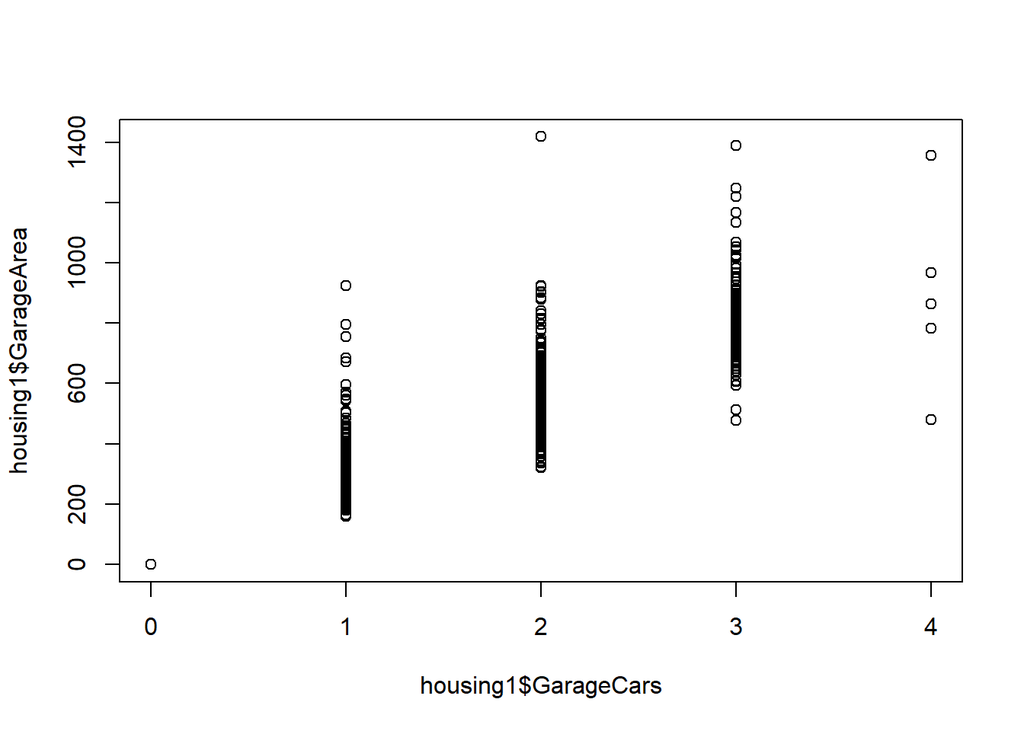

```r
plot(housing1$GarageCars, housing1$GarageArea)
```

```r
anova(lm(housing1$SalePrice~housing1$GarageArea))
```

|  | Df | Sum Sq | Mean Sq | F value | Pr(>F) |
| --- | --- | --- | --- | --- | --- |
| housing1$GarageArea | 1 | 3.578809e+12 | 3.578809e+12 | 926.9513 | 5.265038e-158 |
| Residuals | 1458 | 5.629102e+12 | 3.860838e+09 | NA | NA |

```r
anova(lm(housing1$SalePrice~housing1$GarageCars))
```

|  | Df | Sum Sq | Mean Sq | F value | Pr(>F) |
| --- | --- | --- | --- | --- | --- |
| housing1$GarageCars | 1 | 3.776385e+12 | 3.776385e+12 | 1013.706 | 2.498644e-169 |
| Residuals | 1458 | 5.431526e+12 | 3.725327e+09 | NA | NA |

```r
# Let's drop garage area
# Also garage year built is similar to house year built, drop this as well

housing1 <- select(housing1, -GarageArea, -GarageYrBlt)
```

## Month house sold

There does not seem to be a significant difference of sale price across different months. Therefore this variable is also dropped because otherwise it will be a factor with 12 levels that can overfit the model.

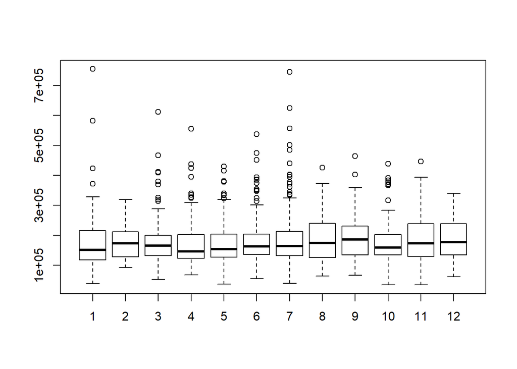

```r
boxplot(housing1$SalePrice~housing1$MoSold)
```

```r
anova(lm(housing1$SalePrice~housing1$MoSold))
```

|  | Df | Sum Sq | Mean Sq | F value | Pr(>F) |
| --- | --- | --- | --- | --- | --- |
| housing1$MoSold | 1 | 1.985183e+10 | 19851827717 | 3.150172 | 0.07612758 |
| Residuals | 1458 | 9.188060e+12 | 6301824079 | NA | NA |

```r
# There does not appear to be a signifcant difference in sale price by month sold
# drop this variable

housing1 <- select(housing1, - MoSold)
```

## Other ordinal ratings

There are a number of other ordinal rating variables in the data. We can recode them with labels just like we did before in the missing data section, so that they can better reflect the information about being good and bad in a particular measure about the house.

```r
## Other ordinal ratings
# ExterQual ExterCond HeatingQC KitchenQual

housing1$ExterQual <- as.integer(recode(housing1$ExterQual,
                                          "Po" = 1,"Fa" = 2, "TA" = 3, "Gd" = 4, "Ex" = 5))

housing1$ExterCond <- as.integer(recode(housing1$ExterCond,
                                          "Po" = 1,"Fa" = 2, "TA" = 3, "Gd" = 4, "Ex" = 5))

housing1$HeatingQC <- as.integer(recode(housing1$HeatingQC,
                                          "Po" = 1,"Fa" = 2, "TA" = 3, "Gd" = 4, "Ex" = 5))

housing1$KitchenQual <- as.integer(recode(housing1$KitchenQual,
                                          "Po" = 1,"Fa" = 2, "TA" = 3, "Gd" = 4, "Ex" = 5))
```

# Model Building

After doing all the feature engineering and dealing with missing data, we can finally build the model. Here I use a validation set approach to compare a number of different regression and machine learning models, including a stepwise selection linear model, lasso, PCR, PLS, Random forest and Boosting.

But before that, I checked the distribution of the Sale Price variable and found it to be non-normal. Therefore I did a log transformation on it and used that as the response variable.

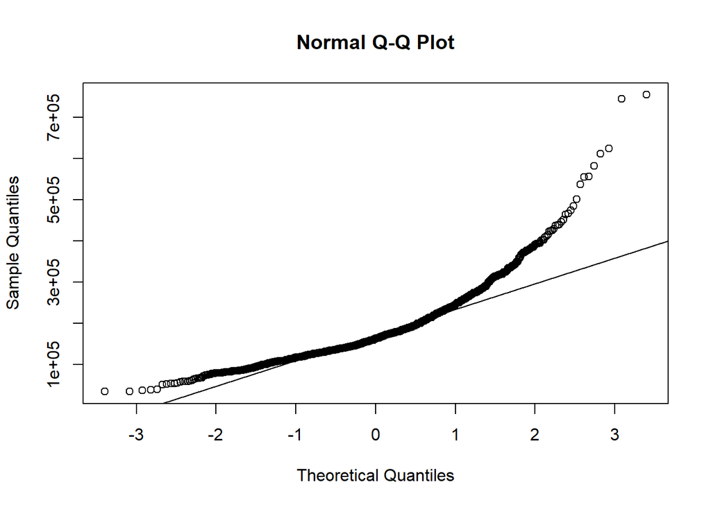

```r
# Check for normality of the y variable
qqnorm(housing1$SalePrice)
qqline(housing1$SalePrice)
```

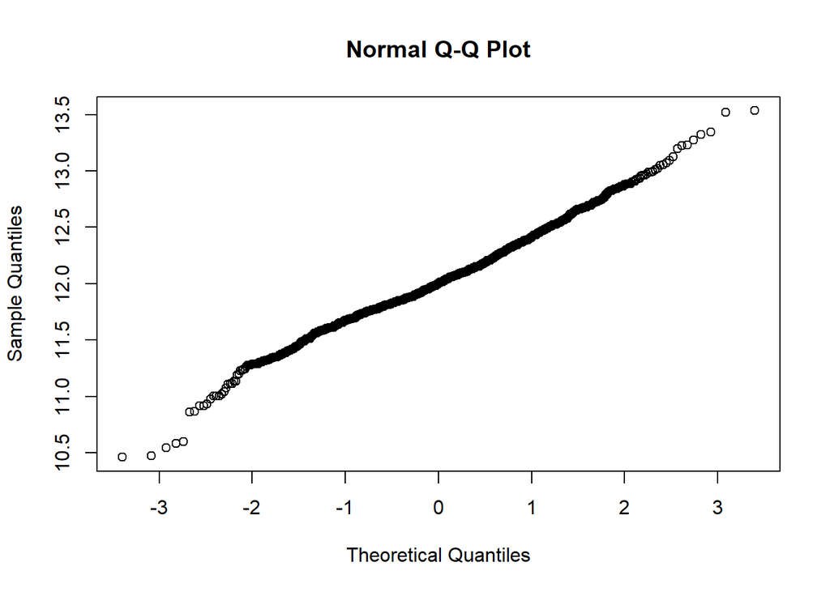

```r
# Transform y log
qqnorm(log(housing1$SalePrice))
```

```r
housing1$SalePrice <- log(housing1$SalePrice)

# Create train and test data set
set.seed(1)
train <- sample(1:nrow(housing1), 1300)
test <- (1:nrow(housing1))[-train]
```

## Stepwise linear selection

```r
library(leaps)

fit.fwd <- regsubsets(SalePrice ~., data = housing1[train,], nvmax = 66, method = "forward")
```

```
## Reordering variables and trying again:
```

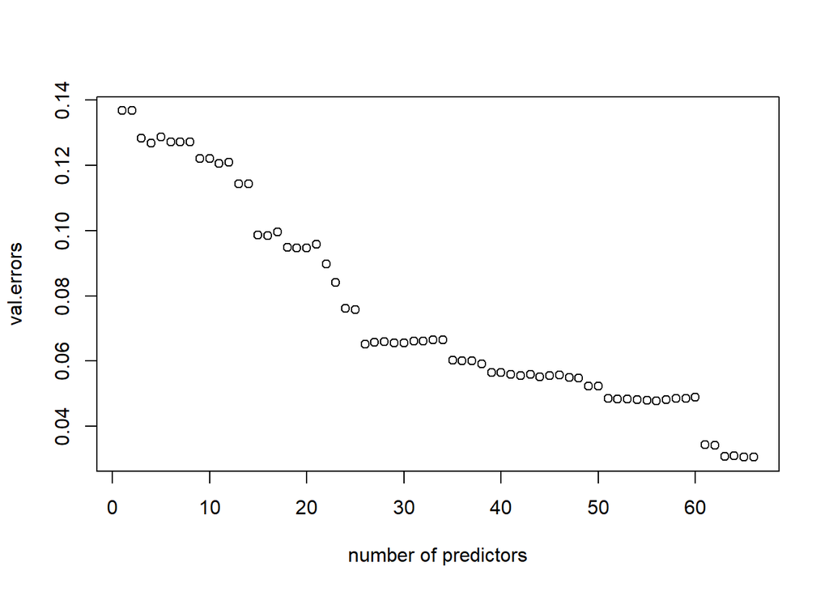

```r
# test error
test.mat <- model.matrix(SalePrice~., data = housing1[test,])
val.errors <- c()
for (i in 1:66) {
  coefi <- coef(fit.fwd, id = i)
  pred <- test.mat[,names(coefi)]%*%coefi
  val.errors[i] <- mean((housing1[test,]$SalePrice - pred)^2)
}

plot(1:66, val.errors, xlab = "number of predictors")
```

```r
which.min(val.errors)
```

```
## [1] 66
```

```r
min(val.errors)
```

```
## [1] 0.03057672
```

Forward selection chooses a model of 66 predictors with a test MSE of 0.03057672 (y = log(Sale Price))

## lasso

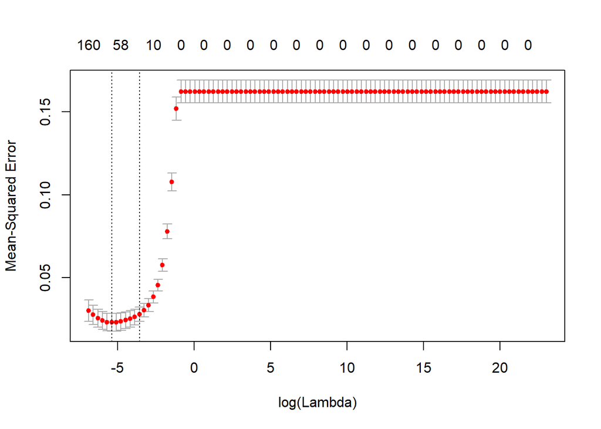

```r
library(glmnet)
x <- model.matrix(SalePrice~., housing1[train,])[,-1]
y <- housing1[train,]$SalePrice

lasso.fit <- glmnet(x, y, alpha = 1, lambda = 10^seq(10, -3, length = 100))

# find the optimal lambda
set.seed(1)
cv.out <- cv.glmnet(x, y, alpha = 1, lambda = 10^seq(10, -3, length = 100))
plot(cv.out)
```

```r
bestlam <- cv.out$lambda.min
bestlam
```

```
## [1] 0.004534879
```

```r
# test error
testx <- model.matrix(SalePrice~., housing1[test,])[,-1]
lasso.pred <- predict(lasso.fit, s = bestlam, newx = testx)
mean((lasso.pred - housing1[test,]$SalePrice)^2)
```

```
## [1] 0.01213894
```

Lasso gives a test error of 0.01213894.

## PCR

For the PCR model, and the PLS model that follows, I also tested a range of tuning parameters to find the one that gives the lowest test error.

```r
library(pls)
library(caret)

tlength <- seq(200,500,10)
mse <- c()
# Build PCR model
set.seed(1)
for (i in 1:length(tlength)){
pcr.fit <- caret::train(SalePrice ~., data = housing1[train,], method = "pcr",
trControl = trainControl("cv", number = 10),
tuneLength = tlength[i])

pcr.pred <- pcr.fit %>% predict(housing1[test,])
mse[i] <- mean((pcr.pred - housing1[test,]$SalePrice)^2)
}

min(mse)
```

```
## [1] 0.01325672
```

```r
tlength[which.min(mse)]
```

```
## [1] 470
```

```r
set.seed(1)
pcr.fit <- caret::train(SalePrice ~., data = housing1[train,], method = "pcr",
trControl = trainControl("cv", number = 10),
tuneLength = 470)

pcr.fit$bestTune
```

|  | ncomp |
| --- | --- |
| 93 | 93 |

The PCR chooses a model with number of components = 93. It gives a test error of around 0.01325672 when using a tuning parameter of 470.

## PLS

```r
tlength <- seq(50,300,10)

mse <- c()
# Build pls model
set.seed(1)
for (i in 1:length(tlength)){
pls.fit <- caret::train(SalePrice ~., data = housing1[train,], method = "pls",
trControl = trainControl("cv", number = 10),
tuneLength = tlength[i])

pls.pred <- pls.fit %>% predict(housing1[test,])
mse[i] <- mean((pls.pred - housing1[test,]$SalePrice)^2)
}

min(mse)
```

```
## [1] 0.01262234
```

```r
tlength[which.min(mse)]
```

```
## [1] 180
```

```r
set.seed(1)
pls.fit <- caret::train(SalePrice ~., data = housing1[train,], method = "pls",
trControl = trainControl("cv", number = 10),
tuneLength = 180)

pls.fit$bestTune
```

|  | ncomp |
| --- | --- |
| 21 | 21 |

PLS selects a model with 21 components and it gives a test error of around 0.01262234 by using a tuning parameter of 180.

## Random Forest

For the random forest and also boosting, I tested a range of different number of trees in order to find one that gives that best model.

```r
library(randomForest)


# Different number of trees
ntree <- seq(500, 2000, 100)

mse <- c()
set.seed(1)
for (i in 1:length(ntree)){
fit.rf <- randomForest(SalePrice ~., data = housing1[train,],
                       ntree = ntree[i], importance = TRUE)

rf.pred <- predict(fit.rf, newdata = housing1[test,])
# test error

mse[i] <- mean((rf.pred - housing1[test,]$SalePrice)^2)
}

min(mse)
```

```
## [1] 0.01446316
```

```r
which.min(mse)
```

```
## [1] 9
```

```r
ntree[which.min(mse)]
```

```
## [1] 1300
```

Random forest gives a test error of around 0.01446316 at number of trees = 1300.

## Boosting

```r
library(gbm)

ntree <- seq(10, 1500, 10 )

mse <- c()
set.seed(1)
for (i in 1:length(ntree)){
fit.boost <- gbm(SalePrice ~., data = housing1[train,], distribution = "gaussian",
                 n.trees = i, interaction.depth = 2)

pred.boosting <- predict(fit.boost, newdata = housing1[test,], n.trees = i)

mse[i] <- mean((pred.boosting - housing1[test,]$SalePrice)^2)
}

ntree[which.min(mse)]
```

```
## [1] 1410
```

```r
min(mse)
```

```
## [1] 0.01873889
```

Boosting gives a lowest test error of 0.01873889 at number of trees = 1410.

# Predict with test data from Kaggle

From the training data test error estimates, it seems our best performing models here are the lasso and the PLS. Here I read in the test data set from kaggle and make predictions on it using these models.

Before that, I need to restructure the test data set just like what I did for the training data including everyting from dealing with NA’s to all the feature engineering. **This is a simple repetition of what I did before therefore you can skip right to the next section to see the prediction result.**

```r
# Read in data
housing <- read.csv("test.csv", header = T)

## Repeat everything that has been done for the training data set

# NA means no alley, we can treat this as another factor level
housing$Alley <- as.character(housing$Alley)
housing$Alley[is.na(housing$Alley)] <- "No alley"
housing$Alley <- factor(housing$Alley)
###

###

# The houses with missing masorny area is also missing masonry type
# Assuming these are houses that do not have a masonry veneer
# Replace NA with "new factor level"None"

housing$MasVnrType <- as.character(housing$MasVnrType)
housing$MasVnrType[is.na(housing$MasVnrType)] <- "None"
housing$MasVnrType <- factor(housing$MasVnrType)

# No masonry wall means there is no area measurements. We can set these to 0 instead of NA
housing$MasVnrArea[is.na(housing$MasVnrArea)] <- 0

# In all these cases regarding basement, NA means no basement, treat NA as another factor level

# a function that substitute NA with a new factor level
nasubfactor <- function(v, repl){
  housing[[v]] <<- as.character(housing[[v]])
  housing[[v]][is.na(housing[[v]])] <<- repl
}

v <- c("BsmtQual", "BsmtCond", "BsmtExposure", "BsmtFinType1", "BsmtFinType2")
invisible(sapply(v, nasubfactor, repl = "No Basement"))


housing$BsmtQual <- as.integer(recode(housing$BsmtQual, "No Basement" = 0,
                           "Po" = 1, "Fa" = 2, "TA" = 3, "Gd" = 4,
                           "Ex" = 5))
housing$BsmtCond <- as.integer(recode(housing$BsmtCond, "No Basement" = 0,
                           "Po" = 1, "Fa" = 2, "TA" = 3, "Gd" = 4,
                           "Ex" = 5))
housing$BsmtExposure <- as.integer(recode(housing$BsmtExposure,
                                          "No Basement" = 0, "No" = 1,
                                          "Mn" = 2, "Av" = 3, "Gd" = 4))
housing$BsmtFinType1 <- as.integer(recode(housing$BsmtFinType1,
                                          "No Basement" = 0, "Unf" = 1,
                                          "LwQ" = 2, "Rec" = 3,
                                          "BLQ" = 4, "ALQ" = 5, "GLQ" = 6))

housing$BsmtFinType2 <- as.integer(recode(housing$BsmtFinType2,
                                          "No Basement" = 0, "Unf" = 1,
                                          "LwQ" = 2, "Rec" = 3,
                                          "BLQ" = 4, "ALQ" = 5, "GLQ" = 6))


levels(housing$FireplaceQu) # Fireplace quality, NA means no fireplace
```

```
## [1] "Ex" "Fa" "Gd" "Po" "TA"
```

```r
nasubfactor(v = "FireplaceQu", repl = "No Fireplace")

housing$FireplaceQu <- as.integer(recode(housing$FireplaceQu,
                                         "No Fireplace" = 0, "Po" = 1,"Fa" = 2, "TA" = 3, "Gd" = 4, "Ex" = 5))

levels(housing$GarageType) # Garage location, NA no garage
```

```
## [1] "2Types"  "Attchd"  "Basment" "BuiltIn" "CarPort" "Detchd"
```

```r
levels(housing$GarageFinish) # Garage finish, NA no garage
```

```
## [1] "Fin" "RFn" "Unf"
```

```r
levels(housing$GarageQual) # Garage quality, NA no garage
```

```
## [1] "Fa" "Gd" "Po" "TA"
```

```r
levels(housing$GarageCond) # Garage condition, NA no garage
```

```
## [1] "Ex" "Fa" "Gd" "Po" "TA"
```

```r
str(housing$GarageYrBlt) # Garage year built
```

```
##  int [1:1459] 1961 1958 1997 1998 1992 1993 1992 1998 1990 1970 ...
```

```r
v <- c("GarageType","GarageFinish", "GarageQual", "GarageCond")
invisible(sapply(v, nasubfactor, repl = "No Garage"))

housing$GarageQual <- as.integer(recode(housing$GarageQual,
                                        "No Garage" = 0, "Po" = 1,"Fa" = 2, "TA" = 3, "Gd" = 4, "Ex" = 5))
housing$GarageCond <- as.integer(recode(housing$GarageCond,
                                        "No Garage" = 0, "Po" = 1,"Fa" = 2, "TA" = 3, "Gd" = 4, "Ex" = 5))

housing$GarageType <- factor(housing$GarageType)
housing$GarageFinish <- factor(housing$GarageFinish)

summary(housing$GarageYrBlt)
```

```
##    Min. 1st Qu.  Median    Mean 3rd Qu.    Max.    NA's
##    1895    1959    1979    1978    2002    2207      78
```

```r
# treat this as a categorical variable

a <- c()
a[which(housing$GarageYrBlt >= 2002)] <- "2002 and newer"
a[which(housing$GarageYrBlt < 2002 & housing$GarageYrBlt >=1980)] <- "1980 ~ 2002"
a[which(housing$GarageYrBlt < 1980 & housing$GarageYrBlt >= 1961)] <- "1961 ~ 1980"
a[which(housing$GarageYrBlt < 1961)] <- "1961 and older"
a[which(is.na(housing$GarageYrBlt))] <- "No Garage"

housing$GarageYrBlt <- factor(a)


levels(housing$PoolQC) # pool quality, NA no pool
```

```
## [1] "Ex" "Gd"
```

```r
nasubfactor("PoolQC", "No Pool")

housing$PoolQC <- as.integer(recode(housing$PoolQC, "No Pool" = 0,
                                    "Po" = 1,"Fa" = 2, "TA" = 3, "Gd" = 4, "Ex" = 5))

levels(housing$Fence) # Fence quality, NA no fence
```

```
## [1] "GdPrv" "GdWo"  "MnPrv" "MnWw"
```

```r
nasubfactor("Fence", "No Fence")
housing$Fence <- as.integer(recode(housing$Fence, "No Fence" = 0,
                                    "MnWw" = 1,"GdWo" = 2, "MnPrv" = 3, "GdPrv" = 4))

levels(housing$MiscFeature) # Miscellaneous feature not covered in other categories, NA means none
```

```
## [1] "Gar2" "Othr" "Shed"
```

```r
nasubfactor("MiscFeature", "None of these")
housing$MiscFeature <- factor(housing$MiscFeature)

str(housing$LotFrontage) # int
```

```
##  int [1:1459] 80 81 74 78 43 75 NA 63 85 70 ...
```

```r
sum(is.na(housing$LotFrontage))
```

```
## [1] 227
```

```r
str(housing$Electrical) # Electrical system
```

```
##  Factor w/ 4 levels "FuseA","FuseF",..: 4 4 4 4 4 4 4 4 4 4 ...
```

```r
levels(housing$Electrical)
```

```
## [1] "FuseA" "FuseF" "FuseP" "SBrkr"
```

```r
sum(is.na(housing$Electrical))
```

```
## [1] 0
```

```r
# so there is only one observation with missing electrical system
# Impute them with KNN

library(DMwR)

housing2 <- knnImputation(data = housing)

sum(is.na(housing2))
```

```
## [1] 0
```

```r
testid <- housing$Id
housing2 <- housing2[,-1]

# MSSubClass is a categorical variable instead of numeric

housing2$MSSubClass <- factor(housing2$MSSubClass)

# Here I create a variable indicating whether the house has been remodeled

housing2$remodel <- ifelse(housing2$YearBuilt == housing2$YearRemodAdd, "No", "Yes")
housing2$remodel <- factor(housing2$remodel)

# In addition, I create a variable house age = year house sold -  year built

housing2$houseage <- housing2$YrSold - housing2$YearBuilt


# Drop the unused year variables

housing2 <- select(housing2, -YearBuilt, - YearRemodAdd, -YrSold)

# Basement, weighted overall finish rating

housing2$BsmtFinrating <- ifelse(housing2$BsmtFinSF1 == 0 & housing2$BsmtFinSF2 == 0, 0,
                                 housing2$BsmtFinSF1*housing2$BsmtFinType1 + housing2$BsmtFinSF2*
                                   housing2$BsmtFinType2/(housing2$BsmtFinSF1 +
                                                             housing2$BsmtFinSF2))

# Total basement area = total finished + total unfinished area
# We don't need all 3 of these meausres
# Drop the total unfinished area

housing2 <- select(housing2, -BsmtUnfSF, -BsmtFinType1, -BsmtFinType2, -BsmtFinSF1, - BsmtFinSF2)

###
# Floor areas

# The above ground living area is basically the sum of 1st floor, 2nd floor, and
# the low quality finished area
# We can drop these individual measurements

# However, here we get the information about how many floors this house has
# We can create a new variable for this
housing2$floors <- ifelse(housing2$X2ndFlrSF == 0, 1, 2)

housing2 <- select(housing2, -X1stFlrSF, -X2ndFlrSF, -LowQualFinSF)

###
# Bathrooms
# I don't think there is a need to divide bathroom numbers into basement and above ground
# Here I calculate the total number of bathrooms in the house, half = 0.5

housing2$bathroom <- housing2$BsmtFullBath + housing2$FullBath +
  0.5*(housing2$BsmtHalfBath+ housing2$HalfBath)

housing2 <- select(housing2, -BsmtFullBath, -FullBath, -BsmtHalfBath, -HalfBath)
###
# Garage
# Garage car capacity and area are pretty similar measures

# Let's drop garage area
# Also garage year built is similar to house year built, drop this as well

housing2 <- select(housing2, -GarageArea, -GarageYrBlt)

###
# Month house sold

# There does not appear to be a signifcant difference in sale price by month sold
# drop this variable

housing2 <- select(housing2, - MoSold)


## Other ordinal ratings
# ExterQual ExterCond HeatingQC KitchenQual

housing2$ExterQual <- as.integer(recode(housing2$ExterQual,
                                          "Po" = 1,"Fa" = 2, "TA" = 3, "Gd" = 4, "Ex" = 5))

housing2$ExterCond <- as.integer(recode(housing2$ExterCond,
                                          "Po" = 1,"Fa" = 2, "TA" = 3, "Gd" = 4, "Ex" = 5))

housing2$HeatingQC <- as.integer(recode(housing2$HeatingQC,
                                          "Po" = 1,"Fa" = 2, "TA" = 3, "Gd" = 4, "Ex" = 5))

housing2$KitchenQual <- as.integer(recode(housing2$KitchenQual,
                                          "Po" = 1,"Fa" = 2, "TA" = 3, "Gd" = 4, "Ex" = 5))
```

# Prediction

Lasso and pls were the two models that performed the best based on training data set. Let’s now build these two models using the full training data available and predict on the test data set.

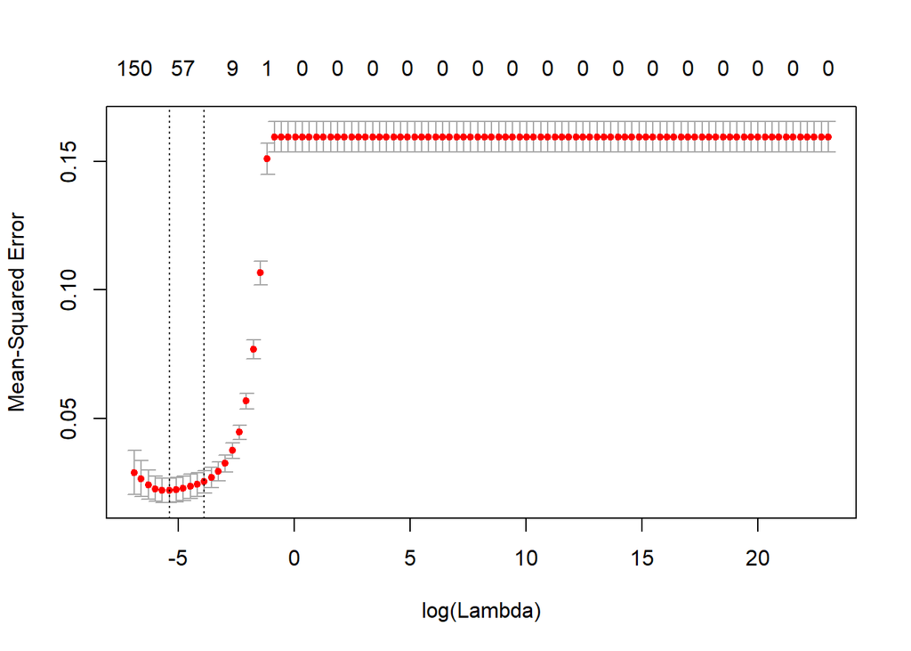

```r
# Combine the full train (housing1) and test (housing2) data sets together
# so that the variables have the same factor levels and won't cause problems in prediction
housing2$SalePrice <- 1
fulldat <-rbind(housing1, housing2)

### Lasso
x <- model.matrix(SalePrice~., fulldat[1:nrow(housing1),])[,-1]
y <- housing1$SalePrice

lasso.fit <- glmnet(x, y, alpha = 1, lambda = 10^seq(10, -3, length = 100))

# find the optimal lambda
set.seed(1)
cv.out <- cv.glmnet(x, y, alpha = 1, lambda = 10^seq(10, -3, length = 100))
plot(cv.out)
```

```r
bestlam <- cv.out$lambda.min
bestlam
```

```
## [1] 0.004534879
```

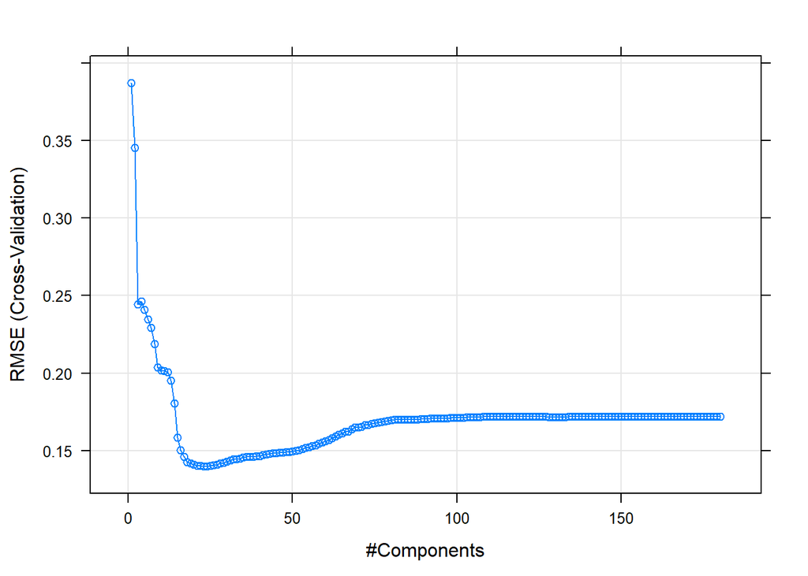

```r
# Predict

testx <- model.matrix(SalePrice~., fulldat[(nrow(housing1)+1):nrow(fulldat),])[,-1]
lasso.pred <- predict(lasso.fit, s = bestlam, newx = testx)

# Covert tranformed y to orignal form
pred1 <- exp(lasso.pred)

# Write the results into csv
write.csv(data.frame(testid,pred1), "lassopred.csv")

###

# PLS
set.seed(1)

# Build pls model
pls.fit <- caret::train(SalePrice ~., data = fulldat[1:nrow(housing1),], method = "pls",
trControl = trainControl("cv", number = 10),
tuneLength = 180)

plot(pls.fit)
```

```r
# Optimal number of components
pls.fit$bestTune
```

|  | ncomp |
| --- | --- |
| 24 | 24 |

```r
pls.pred <- pls.fit %>% predict(fulldat[(nrow(housing1)+1):nrow(fulldat),])

# Covert tranformed y to orignal form
pred2 <- exp(pls.pred)

# Write the results into csv
write.csv(data.frame(testid,pred2), "plspred.csv")
```

Upon submitting the prediction results to Kaggle, it turns out the PLS model gives a better score according to their measure. I had a Kaggle score of 0.12833, and was ranked around 1620 out of 4717 (top 34%) total participants at the time when writing the report.

The final model is summarized below.

```r
summary(pls.fit$finalModel)
```

```
## Data:    X dimension: 1460 214
##  Y dimension: 1460 1
## Fit method: oscorespls
## Number of components considered: 24
## TRAINING: % variance explained
##           1 comps  2 comps  3 comps  4 comps  5 comps  6 comps  7 comps
## X          92.347    99.33    99.63    99.73    99.89    99.97    99.98
## .outcome    9.349    26.37    62.21    63.32    64.34    65.67    68.25
##           8 comps  9 comps  10 comps  11 comps  12 comps  13 comps
## X           99.99    99.99     99.99    100.00     100.0    100.00
## .outcome    71.03    75.49     75.82     75.89      76.1     76.48
##           14 comps  15 comps  16 comps  17 comps  18 comps  19 comps
## X           100.00    100.00    100.00    100.00    100.00    100.00
## .outcome     78.96     85.56     87.29     88.68     89.46     89.95
##           20 comps  21 comps  22 comps  23 comps  24 comps
## X           100.00    100.00    100.00    100.00    100.00
## .outcome     90.29     90.75     90.92     91.11     91.25
```

# Conclusion

The Kaggle test error(RMSE for log(y)) for my PLS model was pretty close to my validation test error(MSE), 0.12833 to $\sqrt{0.01262234} = 0.1123492$. With a principal component number of 24, this model is relatively good in terms of model simplicity, which is probably why it had the best score because of a lower variance.

Although this report only mentioned about 2 final models submitted, there were actually a number of other models tested through Kaggle using different kinds of feature engineering but did not give as good results.

There is definitely room for improvement. Through this work, I found that different ways of tinkering and restructuring the data had a much bigger impact on model performance than the choice of modeling techniques. Therefore if time allows, there can definitely be improvements on the ways of feature engineering so that I can have a better prediction result. In addition, the modeling techniques I chose for this project, although generally considered good, are the ones that all have some degrees of built-in variable selection or cross validation. Perhaps a more complex method for variable selection before building the models can be adopted, and also different types of cross validation can be done for a wider range of model parameters, such as those in the random forest, boosting, and PCR.